# Stationarity of Turkish Electricity Consumption Data

Ümit Barış Gökkaya - IE 360 Fall '20 - 29.01.2021

## 1. Introduction

In the following two weeks, we will try to forecast the total hourly electricity consumption of Turkey as part of the project for IE 360 course.  
As a practice homework, daily mean of the hourly data will be stationarized and forecasted in this analysis.

## 2. Analysis

All data used are from the [EPIAS EXIST Transparency Platform](https://seffaflik.epias.com.tr/transparency/tuketim/gerceklesen-tuketim/gercek-zamanli-tuketim.xhtml). Main tool for achieving stationarity will be the SARIMAX function of statsmodels package. SARIMAX includes both the standard ARIMA modelling tools and the seasonal ARIMA tools.

```python
import pandas as pd
import matplotlib.pyplot as plt
import seaborn as sns

from statsmodels.graphics.tsaplots import plot_acf, plot_pacf
from statsmodels.tsa.stattools import kpss
import statsmodels.tsa.api as tsa

import warnings
warnings.filterwarnings('ignore')
```

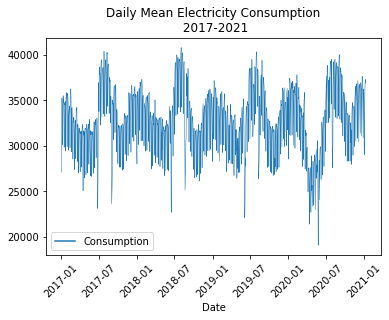

```python
df = pd.read_csv("RealTimeConsumption.csv", index_col="Date", parse_dates=True, dayfirst=True)
df.columns = ["Hour", "Consumption"]
df.Consumption = df.Consumption.str.replace(",", "").astype("float")
df = df.resample("D").Consumption.mean().to_frame()
sns.lineplot(data=df, linewidth=0.5).set_title("Daily Mean Electricity Consumption\n 2017-2021")
plt.xticks(rotation=45);
```

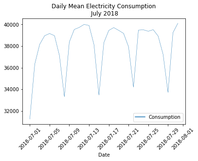

```python
sns.lineplot(data=df.loc["2018-07"], linewidth=0.5).set_title("Daily Mean Electricity Consumption\n July 2018")
plt.xticks(rotation=45);
```

Data in this analysis is between January 1, 2017 and January 8, 2021.

As seen on the initial plot, data is highly non-stationary. It shows weekly seasonality as it can be seen on the second plot. On a bigger scale, it has a monthly trend, which seems to be higher in summer and lower in other months.

Investigating the autocorrelation and partial autocorrelation plots below, we can safely assume that differencing the data once daily and once weekly can help immensely.

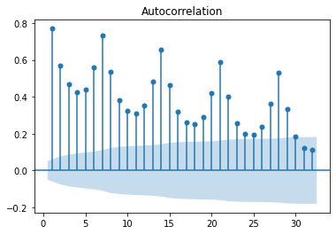

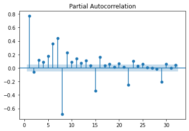

```python
plot_acf(df, zero=False)
plot_pacf(df, zero=False);
```

For differencing, instead of doing it manually, differencing parameters of SARIMAX funtion will be used to keep everything tidy.

```python
ar_model = tsa.SARIMAX(df.Consumption, order=(0, 1, 0), seasonal_order=(0, 1, 0, 7)).fit()
print(ar_model.summary())
print("\n\nKPSS: {}".format(kpss(ar_model.resid)));
```

```
                                     SARIMAX Results
=========================================================================================
Dep. Variable:                       Consumption   No. Observations:                 1469
Model:             SARIMAX(0, 1, 0)x(0, 1, 0, 7)   Log Likelihood              -12725.391
Date:                           Sat, 30 Jan 2021   AIC                          25452.783
Time:                                   10:15:13   BIC                          25458.070
Sample:                               01-01-2017   HQIC                         25454.755
                                    - 01-08-2021
Covariance Type:                             opg
==============================================================================
                 coef    std err          z      P>|z|      [0.025      0.975]
------------------------------------------------------------------------------
sigma2      2.141e+06   3.65e+04     58.708      0.000    2.07e+06    2.21e+06
===================================================================================
Ljung-Box (L1) (Q):                  57.91   Jarque-Bera (JB):              3274.28
Prob(Q):                              0.00   Prob(JB):                         0.00
Heteroskedasticity (H):               1.20   Skew:                             0.05
Prob(H) (two-sided):                  0.04   Kurtosis:                        10.33
===================================================================================

Warnings:
[1] Covariance matrix calculated using the outer product of gradients (complex-step).


KPSS: (0.022139354486147324, 0.1, 24, {'10%': 0.347, '5%': 0.463, '2.5%': 0.574, '1%': 0.739})
```

```
9.815731692958334
```

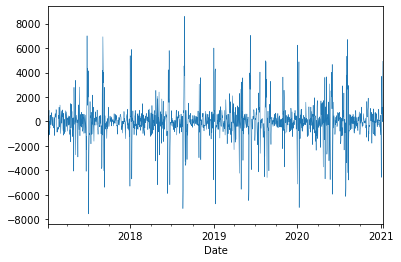

```python
print(ar_model.resid.mean());
ar_model.resid.iloc[8:].plot(linewidth=0.5);
```

Looking at the differenced values and the KPSS test values, data seem stationary. However the mean is not 0, which may be caused by the outliers. To solve this, outlier values will be set to previous 14 days' mean.

```python
outliers = pd.eval("ar_model.resid > ar_model.resid.quantile(0.95) | ar_model.resid < ar_model.resid.quantile(0.05)")
df.Consumption[outliers] = df.rolling(14).Consumption.mean()
df = df.iloc[14:]
```

```
                                     SARIMAX Results
=========================================================================================
Dep. Variable:                       Consumption   No. Observations:                 1455
Model:             SARIMAX(0, 1, 0)x(0, 1, 0, 7)   Log Likelihood              -12880.319
Date:                           Sat, 30 Jan 2021   AIC                          25762.637
Time:                                   10:15:32   BIC                          25767.915
Sample:                               01-15-2017   HQIC                         25764.607
                                    - 01-08-2021
Covariance Type:                             opg
==============================================================================
                 coef    std err          z      P>|z|      [0.025      0.975]
------------------------------------------------------------------------------
sigma2      3.139e+06   3.62e+04     86.755      0.000    3.07e+06    3.21e+06
===================================================================================
Ljung-Box (L1) (Q):                 129.88   Jarque-Bera (JB):             20848.40
Prob(Q):                              0.00   Prob(JB):                         0.00
Heteroskedasticity (H):               0.87   Skew:                             0.41
Prob(H) (two-sided):                  0.13   Kurtosis:                        21.58
===================================================================================

Warnings:
[1] Covariance matrix calculated using the outer product of gradients (complex-step).


KPSS: (0.02186338702780641, 0.1, 24, {'10%': 0.347, '5%': 0.463, '2.5%': 0.574, '1%': 0.739})
```

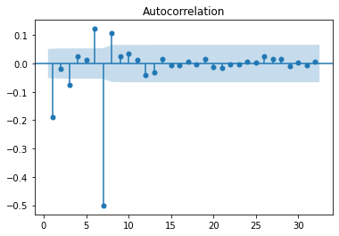

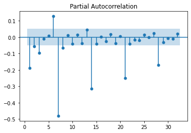

```python
ar_model = tsa.SARIMAX(df.Consumption, order=(0, 1, 0), seasonal_order=(0, 1, 0, 7)).fit()
print(ar_model.summary())
print("\n\nKPSS: {}".format(kpss(ar_model.resid)))
plot_acf(ar_model.resid, zero=False)
plot_pacf(ar_model.resid, zero=False);
```

```
3.669202852690326
```

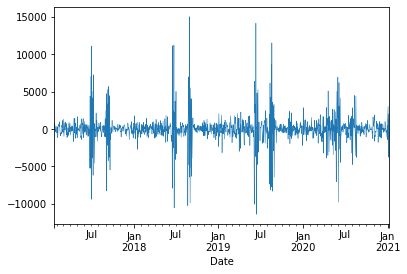

```python
print(ar_model.resid.mean());
ar_model.resid.iloc[8:].plot(linewidth=0.5);
```

The mean is closer to 0, the residuals seem more random. KPSS Test is better.

Now that we have somewhat stationary data, new MA and AR terms will be added to the SARIMAX model to improve forecasting.

The significant autocorrelation at lag 7 and partial autocorrelations at lags 7, 14, 21, 28 may be indicating the need for an seasonal moving average term.

```
                                      SARIMAX Results
===========================================================================================
Dep. Variable:                         Consumption   No. Observations:                 1455
Model:             SARIMAX(0, 1, 0)x(0, 1, [1], 7)   Log Likelihood              -12451.802
Date:                             Sat, 30 Jan 2021   AIC                          24907.605
Time:                                     10:16:17   BIC                          24918.159
Sample:                                 01-15-2017   HQIC                         24911.544
                                      - 01-08-2021
Covariance Type:                               opg
==============================================================================
                 coef    std err          z      P>|z|      [0.025      0.975]
------------------------------------------------------------------------------
ma.S.L7       -0.9999      0.012    -85.957      0.000      -1.023      -0.977
sigma2      1.631e+06   7.15e-09   2.28e+14      0.000    1.63e+06    1.63e+06
===================================================================================
Ljung-Box (L1) (Q):                  83.88   Jarque-Bera (JB):             19372.27
Prob(Q):                              0.00   Prob(JB):                         0.00
Heteroskedasticity (H):               0.71   Skew:                            -0.88
Prob(H) (two-sided):                  0.00   Kurtosis:                        20.84
===================================================================================

Warnings:
[1] Covariance matrix calculated using the outer product of gradients (complex-step).
[2] Covariance matrix is singular or near-singular, with condition number 2.2e+28. Standard errors may be unstable.
```

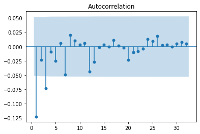

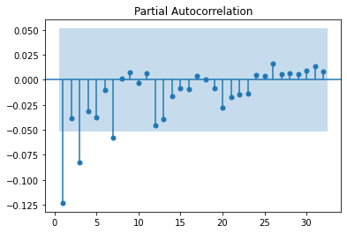

```python
ar_model = tsa.SARIMAX(df.Consumption, order=(0, 1, 0), seasonal_order=(0, 1, 1, 7)).fit()
print(ar_model.summary())
plot_acf(ar_model.resid, zero=False)
plot_pacf(ar_model.resid, zero=False);
```

Significant negative autocorrelation value at lag 1 and gradual decay in PACF are signatures of a MA term.

```
                                     SARIMAX Results
=========================================================================================
Dep. Variable:                       Consumption   No. Observations:                 1455
Model:             SARIMAX(0, 1, 1)x(0, 1, 1, 7)   Log Likelihood              -12390.515
Date:                           Sat, 30 Jan 2021   AIC                          24787.030
Time:                                   10:16:23   BIC                          24802.861
Sample:                               01-15-2017   HQIC                         24792.938
                                    - 01-08-2021
Covariance Type:                             opg
==============================================================================
                 coef    std err          z      P>|z|      [0.025      0.975]
------------------------------------------------------------------------------
ma.L1         -0.3299      0.011    -30.410      0.000      -0.351      -0.309
ma.S.L7       -1.0000      0.012    -83.548      0.000      -1.023      -0.977
sigma2       1.47e+06   8.15e-09    1.8e+14      0.000    1.47e+06    1.47e+06
===================================================================================
Ljung-Box (L1) (Q):                   1.67   Jarque-Bera (JB):             17326.87
Prob(Q):                              0.20   Prob(JB):                         0.00
Heteroskedasticity (H):               0.79   Skew:                            -1.12
Prob(H) (two-sided):                  0.01   Kurtosis:                        19.80
===================================================================================

Warnings:
[1] Covariance matrix calculated using the outer product of gradients (complex-step).
[2] Covariance matrix is singular or near-singular, with condition number 1.7e+28. Standard errors may be unstable.
```

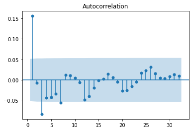

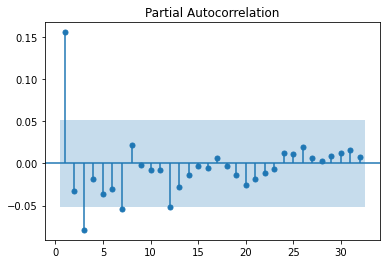

```python
ar_model = tsa.SARIMAX(df.Consumption, order=(0, 1, 1), seasonal_order=(0, 1, 1, 7)).fit()
print(ar_model.summary())
plot_acf(ar_model.resid, zero=False)
plot_pacf(ar_model.resid, zero=False);
```

Additionally, because of the significant autocorrelation at lag 1, an autoregressive term is added.

```
                                     SARIMAX Results
=========================================================================================
Dep. Variable:                       Consumption   No. Observations:                 1455
Model:             SARIMAX(1, 1, 1)x(0, 1, 1, 7)   Log Likelihood              -12377.084
Date:                           Sat, 30 Jan 2021   AIC                          24762.168
Time:                                   10:16:36   BIC                          24783.277
Sample:                               01-15-2017   HQIC                         24770.046
                                    - 01-08-2021
Covariance Type:                             opg
==============================================================================
                 coef    std err          z      P>|z|      [0.025      0.975]
------------------------------------------------------------------------------
ar.L1          0.3443      0.029     11.847      0.000       0.287       0.401
ma.L1         -0.6520      0.025    -25.961      0.000      -0.701      -0.603
ma.S.L7       -1.0000      0.012    -85.411      0.000      -1.023      -0.977
sigma2      1.433e+06   8.17e-09   1.75e+14      0.000    1.43e+06    1.43e+06
===================================================================================
Ljung-Box (L1) (Q):                   0.00   Jarque-Bera (JB):             19501.65
Prob(Q):                              0.97   Prob(JB):                         0.00
Heteroskedasticity (H):               0.73   Skew:                            -1.36
Prob(H) (two-sided):                  0.00   Kurtosis:                        20.78
===================================================================================

Warnings:
[1] Covariance matrix calculated using the outer product of gradients (complex-step).
[2] Covariance matrix is singular or near-singular, with condition number 6.15e+28. Standard errors may be unstable.
```

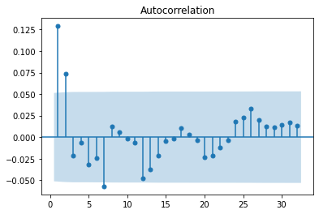

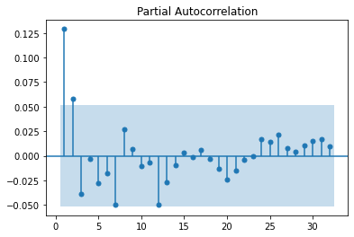

```python
ar_model = tsa.SARIMAX(df.Consumption, order=(1, 1, 1), seasonal_order=(0, 1, 1, 7)).fit()
print(ar_model.summary())
plot_acf(ar_model.resid, zero=False)
plot_pacf(ar_model.resid, zero=False);
```

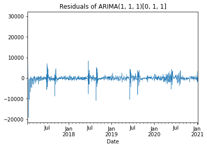

```python
ar_model.resid.plot(linewidth=0.5, title="Residuals of ARIMA(1, 1, 1)[0, 1, 1]");
```

The plot seems a bit off at the beginning, this is because of differencing and ARMA terms used in the model. First two periods of data are ignored for this purpose.

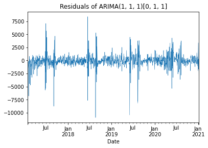

```python
ar_model.resid.iloc[14:].plot(linewidth=0.5, title="Residuals of ARIMA(1, 1, 1)[0, 1, 1]");
```